# PML_Project

## Data Preparation

### Load Data

```r
#load data
training<-read.csv("/Users/Andreas/Library/Mobile Documents/com~apple~CloudDocs/Kurse/2020_11-2021_03 Data Science Statistics and Machine Learning_John Hopkins University/DataScienceSpec_Course8_Practical Machine Learning/Project/pml-training.csv")
testing<-read.csv("/Users/Andreas/Library/Mobile Documents/com~apple~CloudDocs/Kurse/2020_11-2021_03 Data Science Statistics and Machine Learning_John Hopkins University/DataScienceSpec_Course8_Practical Machine Learning/Project/pml-testing.csv")
```

### Data Cleaning and Partition

The dataset has the following dimension:

```r
dim(training)
```

```
## [1] 19622   160
```

However many variables seem empty or NA. This is expected since the excercise movement is quire limited. Empty colums will be removed. For removal a cutoff of 0.97 was used, after experimenting with suitable cutoffs

```r
# identify empty columns
index.empty.train<-which(colSums(is.na(training)|training=="")>0.97*dim(training)[1])
index.empty.test<-which(colSums(is.na(testing)|testing=="")>0.97*dim(testing)[1])
#check for differences between training and testing set
all(index.empty.test %in% index.empty.train)
```

```
## [1] TRUE
```

The same elemnts are empty in both the testing and training dataset. Therefore these values can be deleted

```r
clean.train<-training[,-index.empty.train]
clean.test<-testing[,-index.empty.train]
#also delete columns for housekeeping
clean.train<-clean.train[,-c(1:7)]
clean.test<-clean.test[,-c(1:7)]
#remove project_id column from clean.test since it seems non-random (however, it does not affect the final prediction)
clean.test <- clean.test[,-which(names(clean.test)=="problem_id")]
dim(clean.train)
```

```
## [1] 19622    53
```

```r
dim(clean.test)
```

```
## [1] 20 52
```

## Modeling

In this section training data will be partitioned in a training and validation set,cross validation is set up and predictions of a number of algorithms are tested

### Data Partition

Training data (clean.train) will be partitioned on a training set containing 75% of the data and a validation set contining 25% of the data. The split will be based on the manner participants did the excercise based on the values in the “classe” column

```r
trainset.index<-createDataPartition(clean.train$classe,p=0.75,list=FALSE)
trainset<-clean.train[trainset.index,]
valset<-clean.train[-trainset.index,]
dim(trainset)
```

```
## [1] 14718    53
```

```r
dim(valset)
```

```
## [1] 4904   53
```

### Cross Validation

Cross-Validation is used by training the model muliple times on different proportions of the designated training set (trainset) to obtain better predictions and limit overfitting. For this project data will be partitioned in 5 different folds to limit computation time.

```r
#Cross validation settings
cross.val <- trainControl(method="cv", number=5)
```

### Classification Tree

Since Generlized Linear Models can only be used for 2-class outcomes. Modeling with a classification tree is tested first.

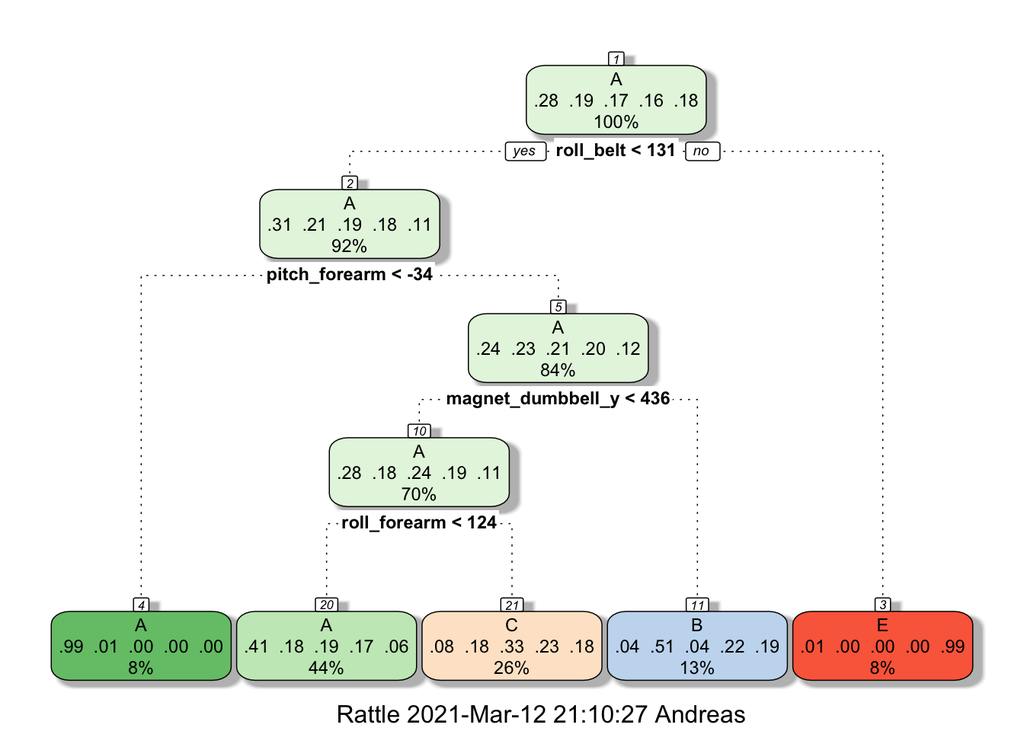

```r
#Training classification tree
CT.fit<-train(classe~.,data=trainset,trControl=cross.val, method="rpart")
fancyRpartPlot(CT.fit$finalModel)
```

```r
CT.pred<-predict(CT.fit,newdata=valset)
CM.CT<-confusionMatrix(CT.pred,valset$classe)
CM.CT
```

```
## Confusion Matrix and Statistics
##
##           Reference
## Prediction    A    B    C    D    E
##          A 1262  410  392  345  132
##          B   26  295   30  149  122
##          C  101  244  433  310  244
##          D    0    0    0    0    0
##          E    6    0    0    0  403
##
## Overall Statistics
##
##                Accuracy : 0.488
##                  95% CI : (0.4739, 0.5021)
##     No Information Rate : 0.2845
##     P-Value [Acc > NIR] : < 2.2e-16
##
##                   Kappa : 0.331
##
##  Mcnemar's Test P-Value : NA
##
## Statistics by Class:
##
##                      Class: A Class: B Class: C Class: D Class: E
## Sensitivity            0.9047  0.31085   0.5064   0.0000  0.44728
## Specificity            0.6355  0.91732   0.7780   1.0000  0.99850
## Pos Pred Value         0.4967  0.47428   0.3251      NaN  0.98533
## Neg Pred Value         0.9437  0.84727   0.8819   0.8361  0.88921
## Prevalence             0.2845  0.19352   0.1743   0.1639  0.18373
## Detection Rate         0.2573  0.06015   0.0883   0.0000  0.08218
## Detection Prevalence   0.5181  0.12684   0.2716   0.0000  0.08340
## Balanced Accuracy      0.7701  0.61409   0.6422   0.5000  0.72289
```

Accuracy is around 50%. This is pretty low. Therefore, other algorithms will be tried to see if it is possible to obtain a better performance-

### Gradient Boosting Method (gbm)

```r
GBM.fit<-train(classe~.,data=trainset,trControl=cross.val,method="gbm",verbose=FALSE)
GBM.pred<- predict(GBM.fit,newdata=valset)
CM.GBM<-confusionMatrix(GBM.pred,valset$classe)
CM.GBM
```

```
## Confusion Matrix and Statistics
##
##           Reference
## Prediction    A    B    C    D    E
##          A 1369   33    0    0    0
##          B   17  892   27    5    9
##          C    7   22  817   22    7
##          D    2    1    9  773   12
##          E    0    1    2    4  873
##
## Overall Statistics
##
##                Accuracy : 0.9633
##                  95% CI : (0.9576, 0.9684)
##     No Information Rate : 0.2845
##     P-Value [Acc > NIR] : < 2.2e-16
##
##                   Kappa : 0.9536
##
##  Mcnemar's Test P-Value : NA
##
## Statistics by Class:
##
##                      Class: A Class: B Class: C Class: D Class: E
## Sensitivity            0.9814   0.9399   0.9556   0.9614   0.9689
## Specificity            0.9906   0.9853   0.9857   0.9941   0.9983
## Pos Pred Value         0.9765   0.9389   0.9337   0.9699   0.9920
## Neg Pred Value         0.9926   0.9856   0.9906   0.9925   0.9930
## Prevalence             0.2845   0.1935   0.1743   0.1639   0.1837
## Detection Rate         0.2792   0.1819   0.1666   0.1576   0.1780
## Detection Prevalence   0.2859   0.1937   0.1784   0.1625   0.1794
## Balanced Accuracy      0.9860   0.9626   0.9706   0.9778   0.9836
```

Accuracy is 96%. Let’s also test a random forrest algorithm

### Random Forrest

```r
RF.fit<-train(classe~.,data=trainset,trControl=cross.val,method="rf",verbose=FALSE)
RF.pred<-predict(RF.fit,newdata=valset)
CM.RF<-confusionMatrix(RF.pred,valset$classe)
CM.RF
```

```
## Confusion Matrix and Statistics
##
##           Reference
## Prediction    A    B    C    D    E
##          A 1394    7    0    0    0
##          B    0  941    3    0    0
##          C    0    1  852   12    0
##          D    0    0    0  792    4
##          E    1    0    0    0  897
##
## Overall Statistics
##
##                Accuracy : 0.9943
##                  95% CI : (0.9918, 0.9962)
##     No Information Rate : 0.2845
##     P-Value [Acc > NIR] : < 2.2e-16
##
##                   Kappa : 0.9928
##
##  Mcnemar's Test P-Value : NA
##
## Statistics by Class:
##
##                      Class: A Class: B Class: C Class: D Class: E
## Sensitivity            0.9993   0.9916   0.9965   0.9851   0.9956
## Specificity            0.9980   0.9992   0.9968   0.9990   0.9998
## Pos Pred Value         0.9950   0.9968   0.9850   0.9950   0.9989
## Neg Pred Value         0.9997   0.9980   0.9993   0.9971   0.9990
## Prevalence             0.2845   0.1935   0.1743   0.1639   0.1837
## Detection Rate         0.2843   0.1919   0.1737   0.1615   0.1829
## Detection Prevalence   0.2857   0.1925   0.1764   0.1623   0.1831
## Balanced Accuracy      0.9986   0.9954   0.9966   0.9920   0.9977
```

The random forrest algorithm results in >99% accuracy. This is the highest accuracy of the tested models. For this project >99% accuracy seems sufficient.

## Predicting the classe of the test set (clean.test)

Out of the three tested algorithms random forrest provided the best accuracy >99%. This model is used to predict the classe of the observation in the test set.

```r
RF.pred<-predict(RF.fit,newdata=clean.test)
RF.pred
```

```
##  [1] B A B A A E D B A A B C B A E E A B B B
## Levels: A B C D E
```